# Exercise Sheet 2

This exercise sheet is an [R Markdown](https://rmarkdown.rstudio.com/) file. To generate an HTML file from it, use the **Knit** button in RStudio.

The *European Soccer Database* contains data on more than 25.000 national football matches from the best European leagues. The aim of this exercise is to present interesting relationships in R using exploratory data analysis and visualization.

First you need to access some tables in the database. To do so, [download the database](https://1drv.ms/u/s!AlrZt1pKHg25gch_i-b1mAbOtWU44Q?e=AMhg1B) and place it in the same folder as this .Rmd file. You can then use the `RSQLite::dbConnect()` function to connect to the database. To access a particular database table and convert it to a `data.frame`, you can use the `tbl_df(dbGetQuery(connection, 'SELECT * FROM table_xyz'))` command as displayed below.

```r
# Load libraries (they need to be installed on the first run via install.packages)
# You do not need to use these libraries, though
library(RSQLite)
library(stringr)
library(ggplot2)
library(dplyr)
library(tidyr)
library(forcats)
library(lubridate)

# connect to database
con <- dbConnect(SQLite(), dbname = "EuropeanSoccer.sqlite")

# table queries
match <- tbl_df(dbGetQuery(con,"SELECT * FROM Match"))
league <- tbl_df(dbGetQuery(con,"SELECT * FROM League"))
```

*Example code for a visualization: Below, you can find a code chunk that contains code to create a basic scatterplot.*

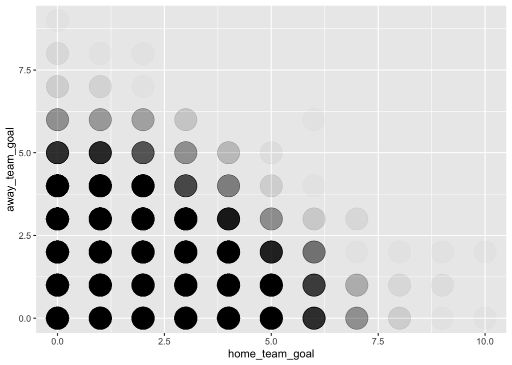

```r
# Example visualization...
match %>%
  ggplot(aes(x = home_team_goal, y = away_team_goal)) +
  geom_point(alpha = 1/50, size = 10)
```

1. The first leagues of Spain, England, Germany and Italy are considered the four most attractive football leagues in Europe. In which of the four leagues were the most or the fewest goals scored per game on average?

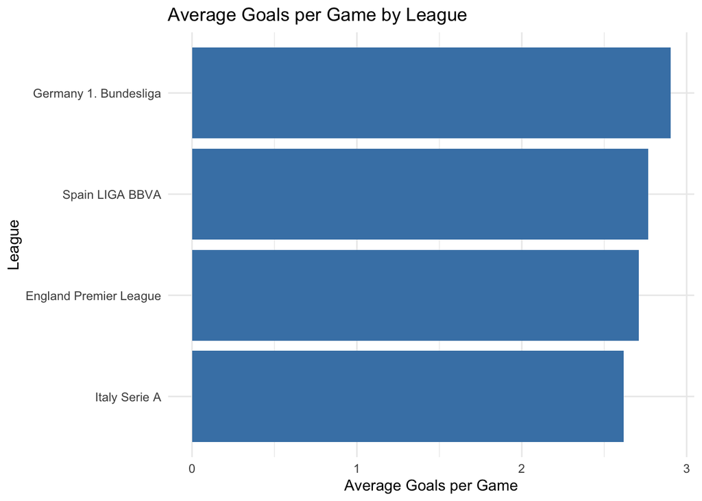

```r
# Solution for task 1...
# First, let's identify the league IDs for the four major leagues
major_leagues <- league %>%
  filter(name %in% c("Spain LIGA BBVA", "England Premier League",
                    "Germany 1. Bundesliga", "Italy Serie A"))

# Calculate average goals per game for each league
match %>%
  inner_join(major_leagues, by = c("league_id" = "id")) %>%
  mutate(total_goals = home_team_goal + away_team_goal) %>%
  group_by(name) %>%
  summarise(avg_goals = mean(total_goals)) %>%
  arrange(desc(avg_goals)) %>%
  ggplot(aes(x = reorder(name, avg_goals), y = avg_goals)) +
  geom_bar(stat = "identity", fill = "steelblue") +
  coord_flip() +
  labs(title = "Average Goals per Game by League",
       x = "League",
       y = "Average Goals per Game") +
  theme_minimal()
```

2. In this task, we refer again to the four most attractive European leagues from Task 1. Compare the average and the standard deviation of goals scored per match between the four most attractive European leagues on one side and the remaining leagues on the other side.

```r
# Solution for task 2...
# Create a comparison between major leagues and other leagues
match %>%
  inner_join(league, by = c("league_id" = "id")) %>%
  mutate(total_goals = home_team_goal + away_team_goal,
         is_major = name %in% c("Spain LIGA BBVA", "England Premier League",
                               "Germany 1. Bundesliga", "Italy Serie A")) %>%
  group_by(is_major) %>%
  summarise(
    avg_goals = mean(total_goals),
    sd_goals = sd(total_goals)
  ) %>%
  mutate(league_type = ifelse(is_major, "Major Leagues", "Other Leagues")) %>%
  select(league_type, avg_goals, sd_goals) %>%
  knitr::kable(digits = 2,
               caption = "Comparison of Goals Statistics between Major and Other Leagues")
```

Comparison of Goals Statistics between Major and Other Leagues

| league_type | avg_goals | sd_goals |
| --- | --- | --- |
| Other Leagues | 2.68 | 1.65 |
| Major Leagues | 2.74 | 1.69 |

3. Is there really a home advantage? Use a box plot to show the number of goals scored by home and away teams.

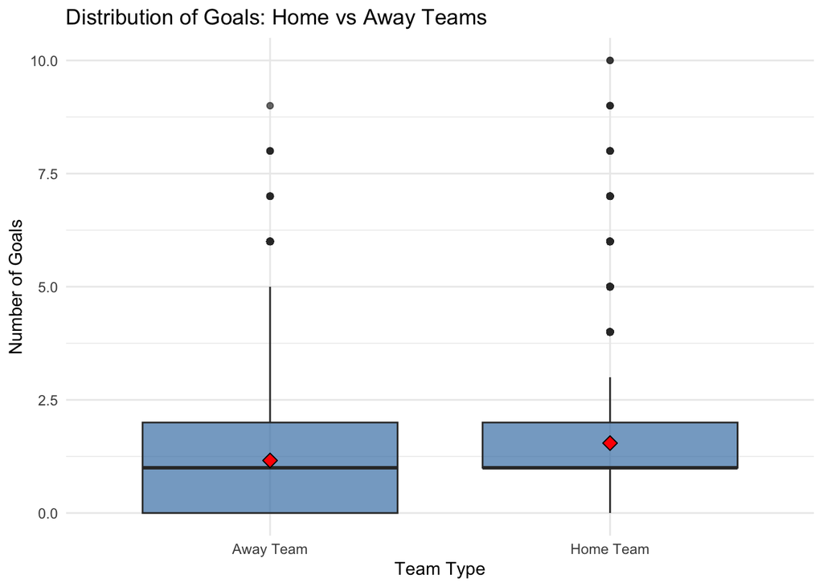

```r
# Solution for task 3...
# Create a box plot comparing home and away goals
match %>%
  select(home_team_goal, away_team_goal) %>%
  pivot_longer(cols = c(home_team_goal, away_team_goal),
               names_to = "team_type",
               values_to = "goals") %>%
  mutate(team_type = ifelse(team_type == "home_team_goal", "Home Team", "Away Team")) %>%
  ggplot(aes(x = team_type, y = goals)) +
  geom_boxplot(fill = "steelblue", alpha = 0.7) +
  labs(title = "Distribution of Goals: Home vs Away Teams",
       x = "Team Type",
       y = "Number of Goals") +
  theme_minimal() +
  stat_summary(fun = mean, geom = "point", shape = 23, size = 3, fill = "red")
```

4. *“All soccer players are fair-weather players!”* Check the assertion with a line chart: Do on average more goals fall per game in the summer months than in the rest of the year?

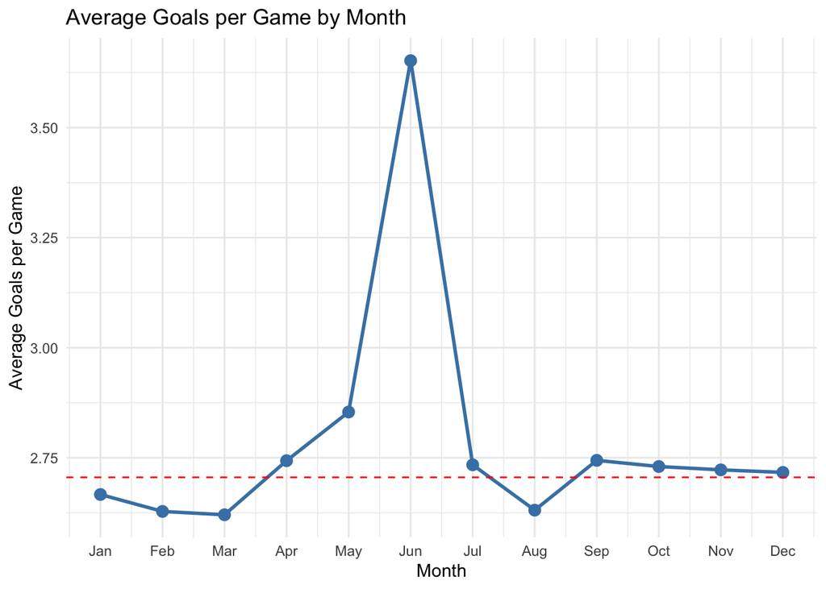

```r
# Solution for task 4...
# Create a line chart showing average goals by month
match %>%
  mutate(month = month(date),
         total_goals = home_team_goal + away_team_goal) %>%
  group_by(month) %>%
  summarise(avg_goals = mean(total_goals)) %>%
  ggplot(aes(x = month, y = avg_goals)) +
  geom_line(color = "steelblue", size = 1) +
  geom_point(color = "steelblue", size = 3) +
  scale_x_continuous(breaks = 1:12,
                    labels = c("Jan", "Feb", "Mar", "Apr", "May", "Jun",
                              "Jul", "Aug", "Sep", "Oct", "Nov", "Dec")) +
  labs(title = "Average Goals per Game by Month",
       x = "Month",
       y = "Average Goals per Game") +
  theme_minimal() +
  # Add a horizontal line for the overall mean
  geom_hline(yintercept = mean(match$home_team_goal + match$away_team_goal),
             color = "red", linetype = "dashed")
```

5. Use an estimated density function curve AND a QQ-Plot to check whether the `home_team_possession` variable is (approximately) normally distributed.

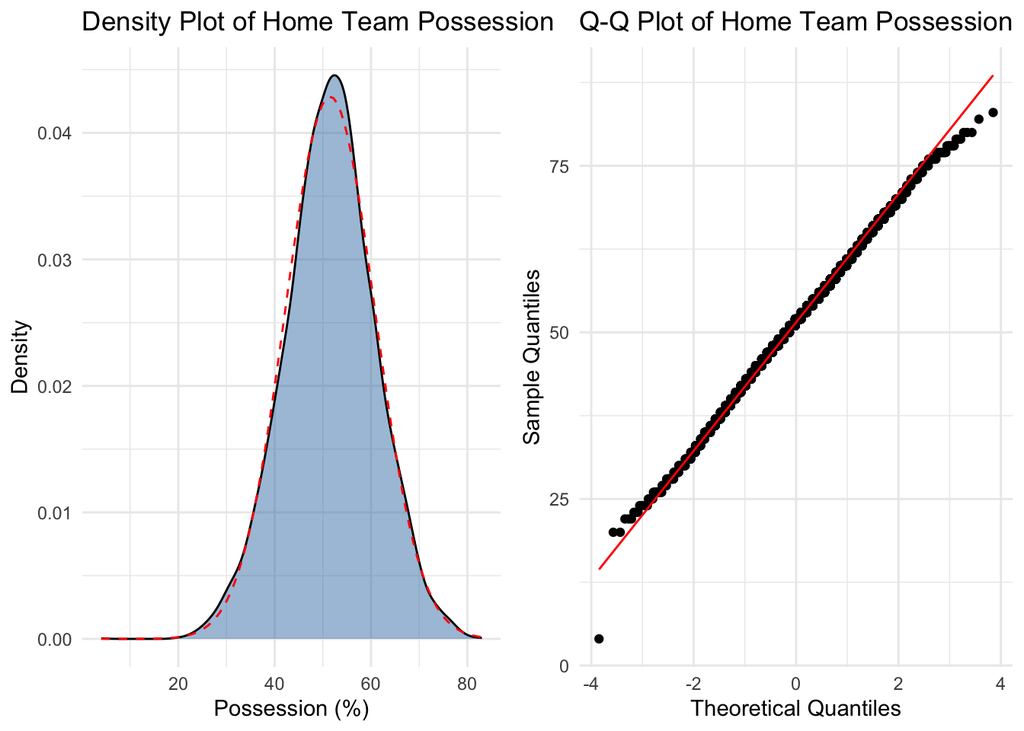

```r
# Solution for task 5...
# Create a density plot and QQ-plot for home team possession
# First, let's create a density plot
p1 <- match %>%
  ggplot(aes(x = home_team_possession)) +
  geom_density(fill = "steelblue", alpha = 0.5) +
  stat_function(fun = dnorm,
                args = list(mean = mean(match$home_team_possession, na.rm = TRUE),
                           sd = sd(match$home_team_possession, na.rm = TRUE)),
                color = "red", linetype = "dashed") +
  labs(title = "Density Plot of Home Team Possession",
       x = "Possession (%)",
       y = "Density") +
  theme_minimal()

# Now create a QQ-plot
p2 <- match %>%
  ggplot(aes(sample = home_team_possession)) +
  stat_qq() +
  stat_qq_line(color = "red") +
  labs(title = "Q-Q Plot of Home Team Possession",
       x = "Theoretical Quantiles",
       y = "Sample Quantiles") +
  theme_minimal()

# Display both plots side by side
gridExtra::grid.arrange(p1, p2, ncol = 2)
```

Dataset:

- https://1drv.ms/u/s!AlrZt1pKHg25gch_i-b1mAbOtWU44Q?e=AMhg1B  
  (For database schema and explanation of variables, see: https://www.kaggle.com/hugomathien/soccer)